# worldcup_predictions

## WORLD CUP PREDICTIONS

This document focuses on predicting football world cup 2018 results based on the previous data collected from fifa’s official website(courtsey by kaggle.com).

# ANALYSIS:-

The data set taken had multiple variables out of which I chose not to use country_abrv, as it had no effect on the outcome. Other variables were transformed and moulded into usable data and then data was split into different clusters and different models were applied on the 2018 data set which was used to predict rankings with odds. One extra variable was added called top5, which indicates if the Team finished in Top5 in that year or not. The raw data had multiple rankings in a year, for example- in year 1993, there were 3 different rankings for every team. Therefore, to remove redundancy and normalise the data, I aggregated the data and used median of the values.

### R code to achieve the ranking predictions

```r
data<-read.csv("fifa_ranking.csv")
year<-format(as.Date(data$rank_date),"%Y")
data$rank_year<-year
data$rank_date<-NULL
data$country_abrv<-NULL
suppressWarnings(library("caTools"))
suppressWarnings(library("caret"))
```

```r
suppressWarnings(library("rpart"))
suppressWarnings(library("rpart.plot"))
suppressWarnings(library("cluster"))
suppressWarnings(library("flexclust"))
suppressWarnings(library("dplyr"))
data1<-data
test2018<-subset(data1,as.character(rank_year)=="2018")
test2018$rank_year<-NULL
conf<-test2018$confederation
test2018$confederation<-NULL

##aggregating the test data
df1<-aggregate(.~ country_full, FUN = median, data=test2018)
test2018$confederation<-conf
a<-aggregate(confederation~ country_full,data = test2018, FUN=unique)
test2018<-cbind(df1,confederation=a[,2])


##aggregating the train data
totaldf<-NULL
years<-unique(data$rank_year)
for(i in years){
  yeardata<-subset(data,rank_year==i)
  yeardata$rank_year<-NULL
  conf<-yeardata$confederation
  yeardata$confederation<-NULL
  df<-aggregate(.~ country_full, FUN = median, yeardata)
  yeardata$confederation<-conf
  a<-aggregate(confederation~ country_full,data = yeardata, FUN=unique)
  df<-cbind(df,confederation=a[,2])
  ##df$rank<-floor(df$rank)
  totaldf<-rbind(totaldf,df)
}




data<-totaldf
data$top5<-ifelse(data$rank<=5,1,0)
data$country_full<-NULL
totaldf1<-totaldf


totaldf<-data
totaldf$confederation<-as.numeric(totaldf$confederation)
totaldf$rank<-NULL
totaldf$top5<-NULL


set.seed(1)
##normalising the data using caret package
preproc<-preProcess(totaldf)
totaldf<-predict(preproc,totaldf)

##clustering the data using k-means algorithm
kmeans<-kmeans(totaldf,centers=6)
clusters<-kmeans$cluster

train1<-subset(data,clusters==1)
train2<-subset(data,clusters==2)
train3<-subset(data,clusters==3)
train4<-subset(data,clusters==4)
train5<-subset(data,clusters==5)
train6<-subset(data,clusters==6)

train1$rank<-NULL
train2$rank<-NULL
train3$rank<-NULL
train4$rank<-NULL
train5$rank<-NULL
train6$rank<-NULL

kmeans.kcca<-as.kcca(kmeans,data=totaldf)
```

```
## Found more than one class "kcca" in cache; using the first, from namespace 'kernlab'
```

```
## Also defined by 'flexclust'
```

```
## Found more than one class "kcca" in cache; using the first, from namespace 'kernlab'
```

```
## Also defined by 'flexclust'
```

```r
temp<-test2018
temp$country_full<-NULL
temp$rank<-NULL
temp$confederation<-as.numeric(temp$confederation)
temp<-predict(preproc,temp)

##predicting clusters of 2018 data
predictedcluster<-predict(kmeans.kcca,newdata=temp)
```

```
## Found more than one class "kcca" in cache; using the first, from namespace 'kernlab'
## Also defined by 'flexclust'
```

```r
suppressWarnings(model1<-glm(top5~.,data = train1,family = "binomial"))
suppressWarnings(model2<-glm(top5~.,data = train2,family = "binomial"))
suppressWarnings(model3<-glm(top5~.,data = train3,family = "binomial"))
suppressWarnings(model4<-glm(top5~.,data = train4,family = "binomial"))
suppressWarnings(model5<-glm(top5~.,data = train5,family = "binomial"))
suppressWarnings(model6<-glm(top5~.,data = train6,family = "binomial"))

##predict for 2018 test dataset

odds<-vector()
k<-1
for(i in predictedcluster){
  if(i==1){
    suppressWarnings(output<-predict(model1,type="response",newdata=test2018[k,]))
    odds <- c(odds, output)
  }
  else if(i==2){
    suppressWarnings(output<-predict(model2,type="response",newdata=test2018[k,]))
    odds <- c(odds, output)
  }
  else if(i==3){
    suppressWarnings(output<-predict(model3,type="response",newdata=test2018[k,]))
    odds <- c(odds, output)
  }
  else if(i==4){
    suppressWarnings(output<-predict(model4,type="response",newdata=test2018[k,]))
    odds <- c(odds, output)
  }
  else if(i==5){
    suppressWarnings(output<-predict(model5,type="response",newdata=test2018[k,]))
    odds <- c(odds, output)
  }
  else if(i==6){
    suppressWarnings(output<-predict(model6,type="response",newdata=test2018[k,]))
    odds <- c(odds, output)
  }
  k<-k+1
}
rankorder<-order(-odds)
odds<-sort(odds,decreasing = TRUE)
rankings<-test2018[rankorder,]
rankings$predicted_rank<-seq(1,211,1)
rankings$odds<-odds
```

### Output

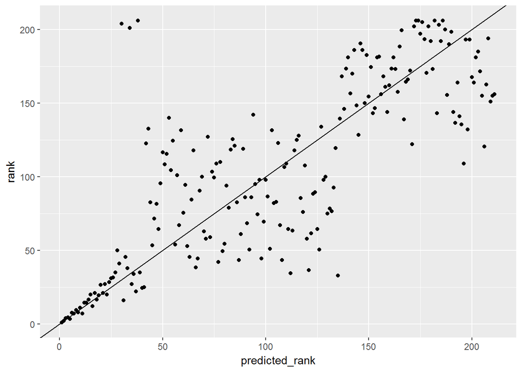

```r
##plotting the predicted vs actual rank graph
ggplot(rankings,aes(x=predicted_rank,y=rank))+geom_point()+geom_abline()
```

```r
write.csv(rankings,"predicted_rankings.csv",row.names = FALSE)
```

### Inference

As seen from the plot, the predictions seems to be very accurate for Top 25 Ranks and begins to deviate from the predicted ranks. The reason being that countries out of Top 25 Rankings have been very inconsistent and haven’t played in all the competitions due to non qualification and hence the data is not abundant as compared to Top25 countries who have played almost every competition and whose data is sufficient enough to predict more accurately. For example, Asian countries see a lot of deviation in their rankings due to limited amount to international football available to them and also due to the confederation they are associated with.